# Code for Course 5 Assignment 1

Set the working directory.

```r
setwd("/users/jhrudey/Desktop/Courses/Datasciencecoursera")
if (!file.exists("RepData_PeerAssessment1")) {
  dir.create("RepData_PeerAssessment1")
}
```

The remote repository was cloned with git to the local repository. Now unzip the files.

```r
unzip("./activity.zip", exdir="./")
list.files("./")
```

```
## [1] "activity.csv"      "activity.zip"      "doc"
## [4] "instructions_fig"  "PA1_template.html" "PA1_template.Rmd"
## [7] "README.md"
```

Read in the csv. Format the date variable.

```r
data <- read.csv("activity.csv", header = TRUE, sep=",", na.strings = "NA")
```

Review the dataset’s properties.

```r
head(data)
```

```
##   steps       date interval
## 1    NA 2012-10-01        0
## 2    NA 2012-10-01        5
## 3    NA 2012-10-01       10
## 4    NA 2012-10-01       15
## 5    NA 2012-10-01       20
## 6    NA 2012-10-01       25
```

```r
tail(data)
```

```
##       steps       date interval
## 17563    NA 2012-11-30     2330
## 17564    NA 2012-11-30     2335
## 17565    NA 2012-11-30     2340
## 17566    NA 2012-11-30     2345
## 17567    NA 2012-11-30     2350
## 17568    NA 2012-11-30     2355
```

```r
str(data)
```

```
## 'data.frame':    17568 obs. of  3 variables:
##  $ steps   : int  NA NA NA NA NA NA NA NA NA NA ...
##  $ date    : Factor w/ 61 levels "2012-10-01","2012-10-02",..: 1 1 1 1 1 1 1 1 1 1 ...
##  $ interval: int  0 5 10 15 20 25 30 35 40 45 ...
```

Format the date variable.

```r
data$date <- as.Date(data$date)
str(data)
```

```
## 'data.frame':    17568 obs. of  3 variables:
##  $ steps   : int  NA NA NA NA NA NA NA NA NA NA ...
##  $ date    : Date, format: "2012-10-01" "2012-10-01" ...
##  $ interval: int  0 5 10 15 20 25 30 35 40 45 ...
```

Aggregate the data to determine the total number of steps taken per day.

```r
stepsdaytotal<- aggregate(steps~date, data, sum, na.rm=TRUE)
```

Create the histogram of the total number of steps per day.

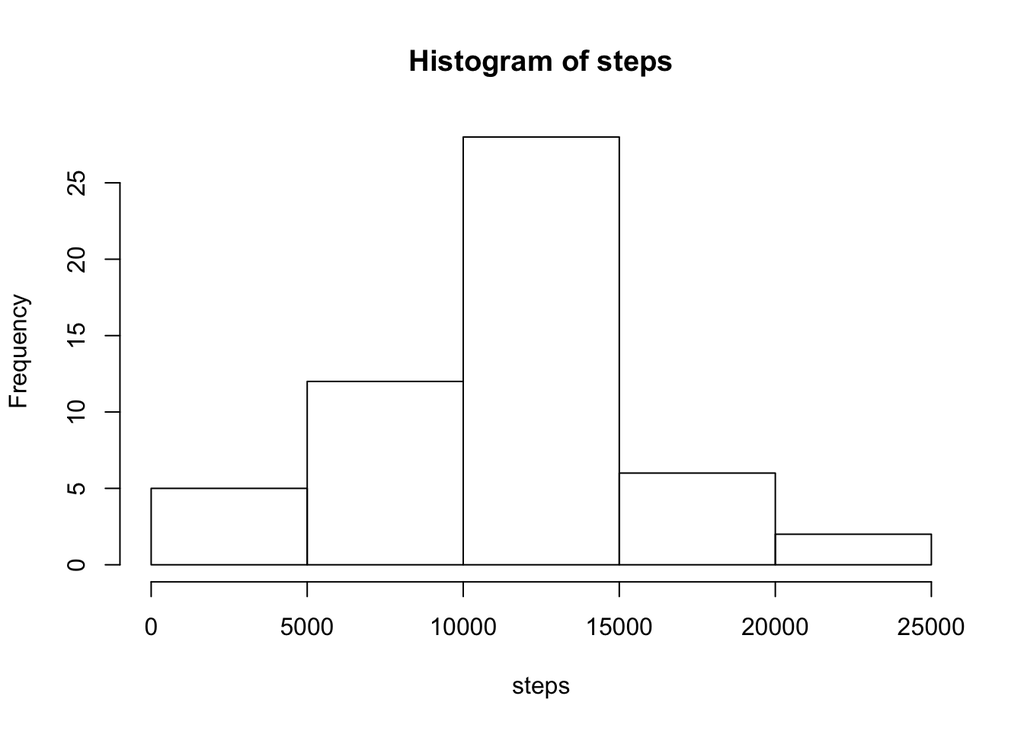

```r
with(stepsdaytotal, hist(steps))
```

```r
dev.copy(png, file = "./instructions_fig/plot1.png", width = 480, height = 480, units = "px")
```

```r
dev.off()
```

Calculate the mean and median of the total number of steps per day.

```r
mean(stepsdaytotal$steps, na.rm=TRUE)
```

```
## [1] 10766.19
```

```r
median(stepsdaytotal$steps, na.rm=TRUE)
```

```
## [1] 10765
```

The mean is 10766.19 and the median is 10765.

Aggregate the data to determine the mean number of steps per interval averaged across all days.

```r
stepsdaymean<- aggregate(steps~interval, data, mean, na.rm=TRUE)
```

Plot the average number of steps over all days per interval with a line graph.

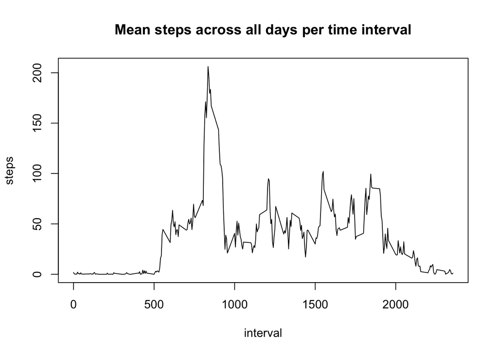

```r
with(stepsdaymean, plot(interval, steps, type="l", main = "Mean steps across all days per time interval"))
```

```r
dev.copy(png, file = "./instructions_fig/plot2.png", width = 480, height = 480, units = "px")
```

```r
dev.off()
```

Determine the interval where the maximum, on average, number of steps were taken by sorting the aggregated dataframe descending by number of steps.

```r
stepsdaymean<- stepsdaymean[with(stepsdaymean, order(steps, decreasing = TRUE)),]
head(stepsdaymean)
```

```
##     interval    steps
## 104      835 206.1698
## 105      840 195.9245
## 107      850 183.3962
## 106      845 179.5660
## 103      830 177.3019
## 101      820 171.1509
```

Interval 835 has the most steps on overage over all days.

Impute the mean steps on average per interval over all days into the the missing values of steps. To do this first merge the variable with the average number of steps per interval into the main dataset.

```r
data2 <- merge(data, stepsdaymean, by="interval")
str(data2)
```

```
## 'data.frame':    17568 obs. of  4 variables:
##  $ interval: int  0 0 0 0 0 0 0 0 0 0 ...
##  $ steps.x : int  NA 0 0 0 0 0 0 0 0 0 ...
##  $ date    : Date, format: "2012-10-01" "2012-11-23" ...
##  $ steps.y : num  1.72 1.72 1.72 1.72 1.72 ...
```

```r
data2$steps.x <- as.numeric(data2$steps.x)
str(data2)
```

```
## 'data.frame':    17568 obs. of  4 variables:
##  $ interval: int  0 0 0 0 0 0 0 0 0 0 ...
##  $ steps.x : num  NA 0 0 0 0 0 0 0 0 0 ...
##  $ date    : Date, format: "2012-10-01" "2012-11-23" ...
##  $ steps.y : num  1.72 1.72 1.72 1.72 1.72 ...
```

Then replace the NA values with the value of the mean steps per interval

```r
data2$steps.x[is.na(data2$steps.x)]<-data2$steps.y[is.na(data2$steps.x)]
library(plyr)
data2 <- rename(data2, c("steps.x"="steps"))
```

Recreate the histogram of the total steps per day and mean and median of the steps per day, but with the imputed dataset.

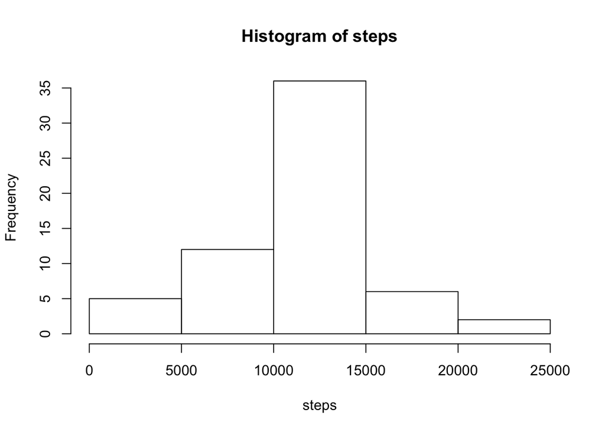

```r
stepsdaytotal2<- aggregate(steps~date, data2, sum, na.rm=TRUE)

with(stepsdaytotal2, hist(steps))
```

```r
dev.copy(png, file = "./instructions_fig/plot3.png", width = 480, height = 480, units = "px")
```

```r
dev.off()
```

```r
mean(stepsdaytotal2$steps, na.rm=TRUE)
```

```
## [1] 10766.19
```

```r
median(stepsdaytotal2$steps, na.rm=TRUE)
```

```
## [1] 10766.19
```

The mean didn’t change in the imputed dataset (10766.19), but the median was affected by imputation (it changed to 10766.19).

Create a variable to determine which steps were taken on weekends and which on weekdays.

```r
data2$Weekday <- as.factor(weekdays(data2$date))

data2$Week <- as.factor(ifelse(data2$Weekday == "Saturday"|data2$Weekday=="Sunday"
                     ,"Weekend","Weekday"))

dataWeekday <- subset(data2, Week == "Weekday")
dataWeekend <- subset(data2, Week == "Weekend")
```

Make subsets of the data for weekdays and for weekends.

```r
dataWeekday <- subset(data2, Week == "Weekday")
dataWeekend <- subset(data2, Week == "Weekend")
```

Determine the mean steps per interval in the weekday dataset and the weekend dataset

```r
stepsdaymeanweekday<- aggregate(steps~interval, dataWeekday, mean, na.rm=TRUE)
stepsdaymeanweekend<- aggregate(steps~interval, dataWeekend, mean, na.rm=TRUE)
```

Plot the mean steps per interval on weekdays and on weekends

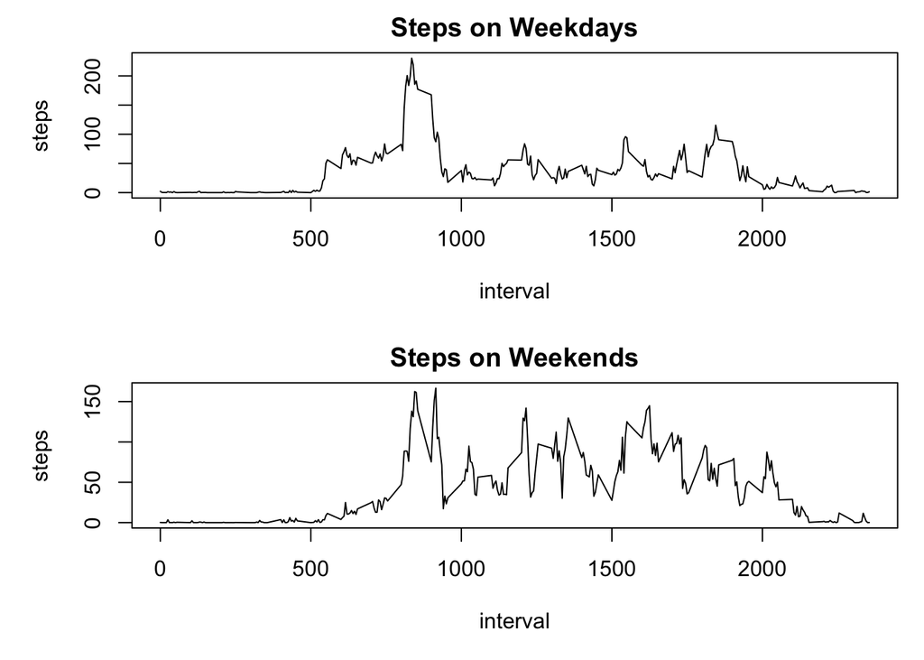

```r
par(mfrow = c(2,1))
par(mar=c(5,5,2,1))
with(stepsdaymeanweekday, plot(interval, steps, type="l", main = "Steps on Weekdays"))
with(stepsdaymeanweekend, plot(interval, steps, type="l", main = "Steps on Weekends"))
```

```r
dev.copy(png, file = "./instructions_fig/plot4.png", width = 480, height = 480, units = "px")
```

```r
dev.off()
```